# 다변량자료분석 HW5

‘수학과 201521139 이재학’

2021-04-15

### *HW5-1.Inferences about mean vectors*

##### **데이터 불러오기**

```r
sweat<-read.table("C:/Users/이재학/Desktop/sweat.txt")
colnames(sweat)<-c("index","sweat rate","sodium content","potassium content")
sweat
```

```
##    index sweat rate sodium content potassium content
## 1      1        3.7           48.5               9.3
## 2      2        5.7           65.1               8.0
## 3      3        3.8           47.2              10.9
## 4      4        3.2           53.2              12.0
## 5      5        3.1           55.5               9.7
## 6      6        4.6           36.1               7.9
## 7      7        2.4           24.8              14.0
## 8      8        7.2           33.1               7.6
## 9      9        6.7           47.4               8.5
## 10    10        5.4           54.1              11.3
## 11    11        3.9           36.9              12.7
## 12    12        4.5           58.8              12.3
## 13    13        3.5           27.8               9.8
## 14    14        4.5           40.2               8.4
## 15    15        1.5           13.5              10.1
## 16    16        8.5           56.4               7.1
## 17    17        4.5           71.6               8.2
## 18    18        6.5           52.8              10.9
## 19    19        4.1           44.1              11.2
## 20    20        5.5           40.9               9.4
```

##### **(a) Determine the axes of the 90% confidence elipsoid for μ and the lengths of theses axes.**

##### **데이터 통계치 구하기**

```r
x_data<-sweat[,2:4]             # 행 번호를 제외한 변수들
xbar<-apply(x_data,2,mean)      # 평균벡터
xvar<-var(x_data)               # 공분산 행렬
p<-nrow(xvar)                   # p=3
n<-nrow(x_data)                 # n=20
```

##### **공분산행렬의 고유값 및 고유 벡터 구하기**

```r
eigen(xvar)
```

```
## eigen() decomposition
## $values
## [1] 200.462464   4.531591   1.301392
##
## $vectors
##             [,1]        [,2]        [,3]
## [1,] -0.05084144 -0.57370364  0.81748351
## [2,] -0.99828352  0.05302042 -0.02487655
## [3,]  0.02907156  0.81734508  0.57541452
```

```r
eve<-eigen(xvar)$vectors
eva<-eigen(xvar)$values
```

##### **1.Determine the axes**

```r
axes<-matrix(rep(0,p^2),nrow=p)        # pxp 영행렬 만들기
for(i in 1:length(eva)){
  axes[,i]<-sqrt(eva[i])*sqrt((n-1)*p/(n*(n-p))*qf(0.90,3,17))*eve[,i]
}
                                       # 반복문을 통해 axes 구하기
axes
```

```
##            [,1]        [,2]        [,3]
## [1,] -0.4601493 -0.78068768  0.59613898
## [2,] -9.0351388  0.07214943 -0.01814089
## [3,]  0.2631172  1.11223146  0.41961339
```

##### **2. Length of these axes**

```r
axes_length<-rep(0,3)                  # px1 영벡터 만들기
for(i in 1:length(eva)){
  axes_length[i]<-sqrt(eva[i])*sqrt((n-1)*p/(n*(n-p))*qf(0.90,3,17))
}                                      # 반복문을 통해 axes_lenth 구하기
axes_length
```

```
## [1] 9.0506741 1.3607857 0.7292367
```

##### **축 요약**

```r
axes_total<-rbind(axes,axes_length)
colnames(axes_total)<-c("axes1","axes2","axes3")
axes_total
```

```
##                  axes1       axes2       axes3
##             -0.4601493 -0.78068768  0.59613898
##             -9.0351388  0.07214943 -0.01814089
##              0.2631172  1.11223146  0.41961339
## axes_length  9.0506741  1.36078566  0.72923671
```

### **(b) Construct QQ plots**

##### **consturct qq plots respectively**

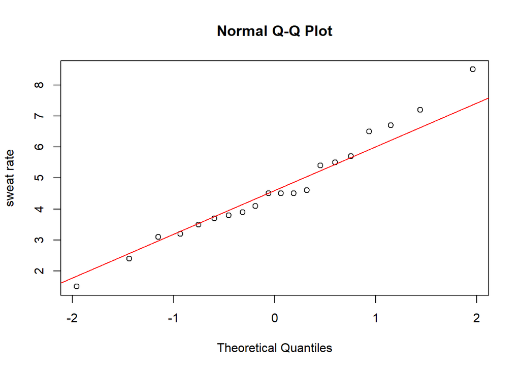

```r
qqnorm(x_data[,1],ylab="sweat rate")
qqline(x_data[,1],col='red')
```

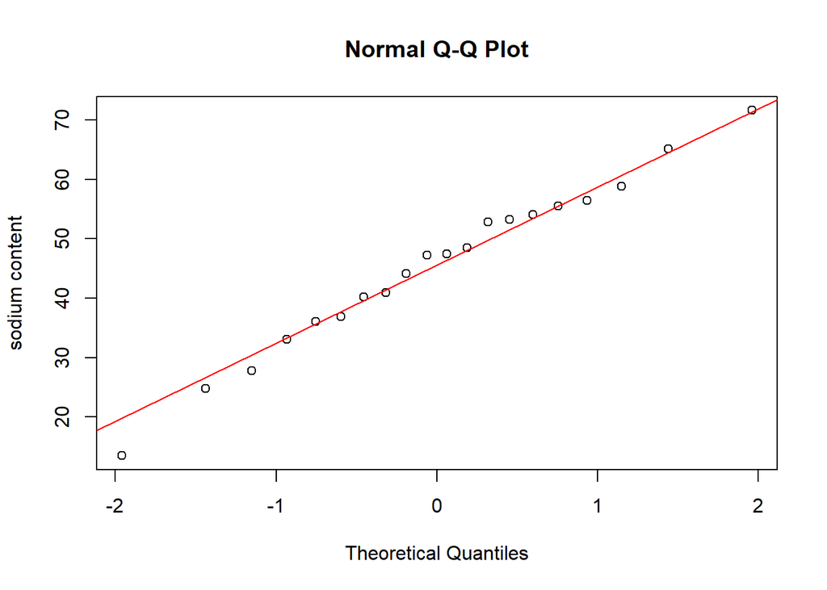

```r
qqnorm(x_data[,2],ylab="sodium content")
qqline(x_data[,2],col='red')
```

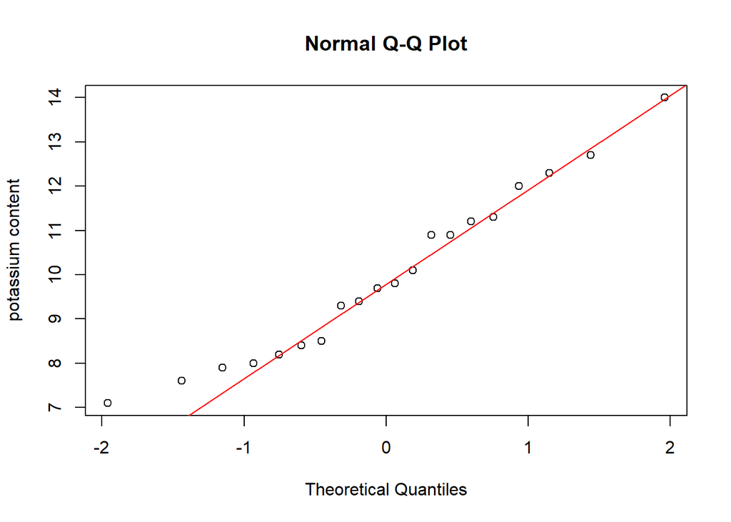

```r
qqnorm(x_data[,3],ylab="potassium content")
qqline(x_data[,3],col='red')
```

##### **consturct the three possible scatter plots for pairs of observations**

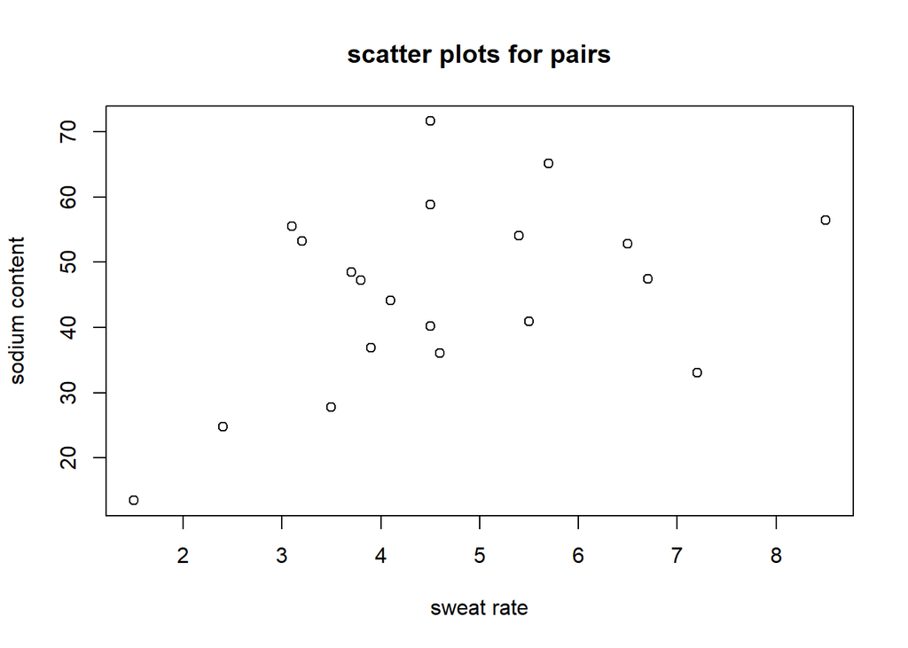

```r
plot(x_data[,1],x_data[,2],main='scatter plots for pairs',xlab='sweat rate',ylab='sodium content')
```

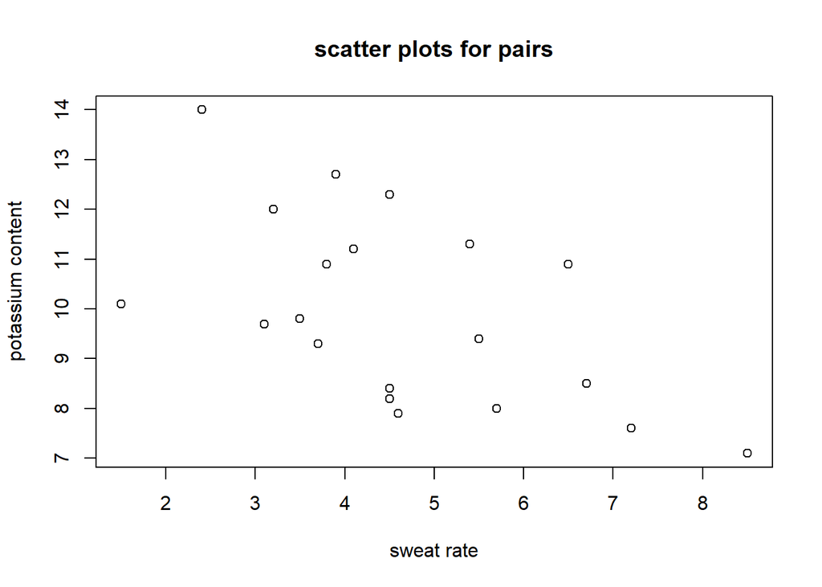

```r
plot(x_data[,1],x_data[,3],main='scatter plots for pairs',xlab='sweat rate',ylab='potassium content')
```

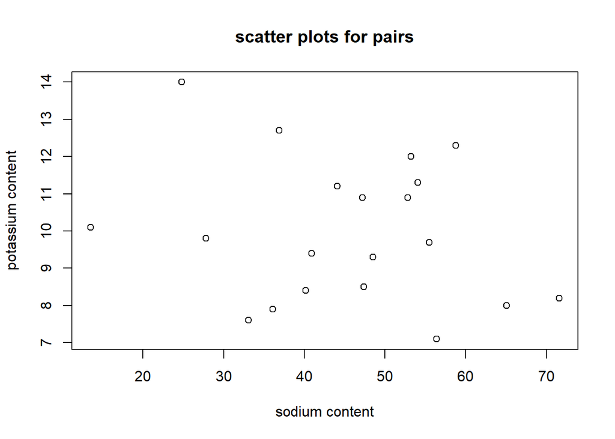

```r
plot(x_data[,2],x_data[,3],main='scatter plots for pairs',xlab='sodium content',ylab='potassium content')
```

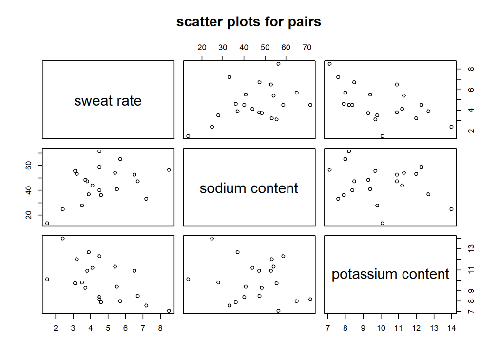

```r
plot(x_data,main='scatter plots for pairs')
```

##### QQplot을 그렸을 때, sweat rate의 몇가지 data를 제외하고서는, 정규성을 만족함을 살펴 볼 수 있고, 두개씩 묶어 본 세가지의 scatter plot을 보고나면, 특정 패턴없이 random 하게 분포 돼있음을 확인할 수 있다.

### **(c) Find confidence intervals**

##### **simultaneous 95% T<sup>2</sup> confidence interval**

```r
lower_simul<-xbar-sqrt(p*(n-1)/(n-p)*qf(0.95,p,n-p))*sqrt(diag(xvar)/n)
upper_simul<-xbar+sqrt(p*(n-1)/(n-p)*qf(0.95,p,n-p))*sqrt(diag(xvar)/n)
CI_simul<-cbind(lower_simul,upper_simul)
CI_simul<-as.data.frame(CI_simul)
CI_simul
```

```
##                   lower_simul upper_simul
## sweat rate           3.397768    5.882232
## sodium content      35.052408   55.747592
## potassium content    8.570664   11.359336
```

##### **Bonferroni intervals**

```r
lower_bon<-xbar-qt((1-0.05/2/p),n-1)*sqrt(diag(xvar)/n)
upper_bon<-xbar+qt((1-0.05/2/p),n-1)*sqrt(diag(xvar)/n)
CI_bon<-cbind(lower_bon,upper_bon)
CI_bon<-as.data.frame(CI_bon)
CI_bon
```

```
##                   lower_bon upper_bon
## sweat rate         3.643952  5.636048
## sodium content    37.103078 53.696922
## potassium content  8.846992 11.083008
```

##### compare the two sets of inervals 를 했을때,Bonferroni intervals의 경우 수업시간에 배운것처럼, 조금 더 보수적인 면모를 보여준다. simultaneous intervals보다 더 좁고 더 정확하다는 의미 이기도 하다.

### *HW5-2.Inferences about mean vectors*

##### **데이터 불러오기**

```r
turtles<-read.table("C:/Users/이재학/Desktop/turtles.txt",header=T)
head(turtles)
```

```
##   gender length width height
## 1      1     98    81     38
## 2      1    103    84     38
## 3      1    103    86     42
## 4      1    105    86     42
## 5      1    109    88     44
## 6      1    123    92     50
```

##### **(a) Test for equalilty of the two polpulation (male/female) mean vectors using α=0.05**

##### **성별 별로 데이터 나누기**

```r
turtles_m<-subset(turtles,gender==1)
turtles_f<-subset(turtles,gender==2)
turtles_m<-turtles_m[,2:4]
turtles_f<-turtles_f[,2:4]
head(turtles_m)
```

```
##   length width height
## 1     98    81     38
## 2    103    84     38
## 3    103    86     42
## 4    105    86     42
## 5    109    88     44
## 6    123    92     50
```

```r
head(turtles_f)
```

```
##    length width height
## 25     93    74     37
## 26     94    78     35
## 27     96    80     35
## 28    101    84     39
## 29    102    85     38
## 30    103    81     37
```

##### **통계치 구하기**

```r
turtles_m_m<-apply(turtles_m,2,mean)
turtles_f_m<-apply(turtles_f,2,mean)
turtles_m_v<-var(turtles_m)
turtles_f_v<-var(turtles_f)
turtles_d<-turtles_m_m-turtles_f_m
n1<-nrow(turtles_m)
n2<-nrow(turtles_f)
p<-nrow(turtles_m_v)
sp<-((n1-1)*turtles_m_v+(n2-1)*turtles_f_v)/(n1+n2-2)
sp
```

```
##          length     width    height
## length 295.1431 175.06069 101.66486
## width  175.0607 110.88678  61.74909
## height 101.6649  61.74909  37.99819
```

##### **테스트**

```r
t(turtles_d)%*%solve(sp*(1/n1+1/n2))%*%turtles_d<=p*(n1+n2-2)/(n1+n2-p-1)*qf(0.95,p,n1+n2-p-1)
```

```
##       [,1]
## [1,] FALSE
```

*따라서,성별로 나눈 거북이의 특성에관한 평균은 α=0.05 하에서 ,통계적으로 유의하게 다르다고 할 수 있다.*

##### **(b) Check model assumptions of common variance and multivariate normality**

##### **1.multivariate normality**

###### **성별에 따른 변수 한개씩**

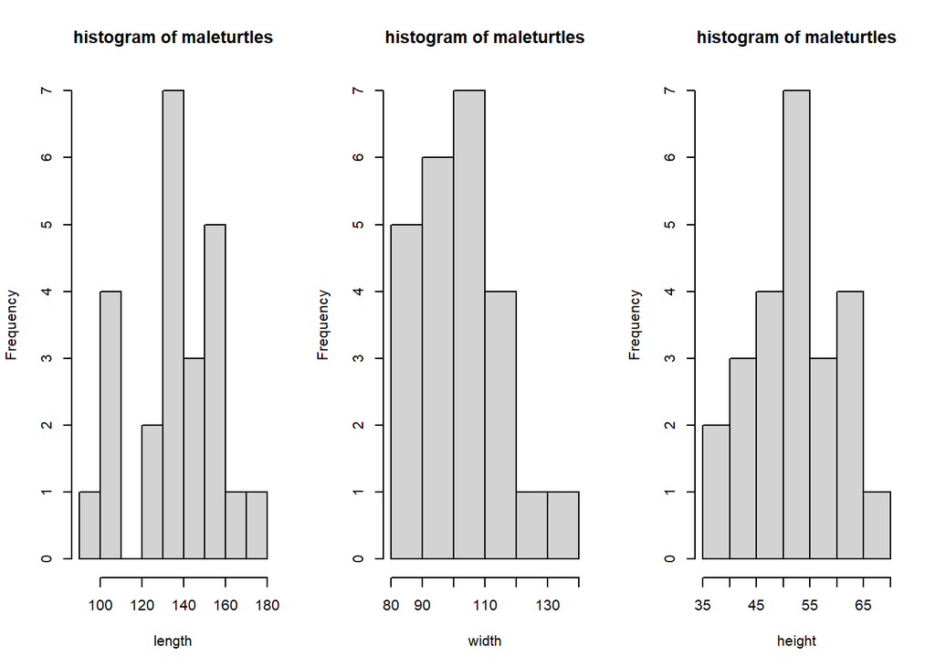

```r
par(mfrow=c(1,3))
hist(turtles_m[,1],main="histogram of maleturtles",xlab=colnames(turtles_m[1]))
hist(turtles_m[,2],main="histogram of maleturtles",xlab=colnames(turtles_m[2]))
hist(turtles_m[,3],main="histogram of maleturtles",xlab=colnames(turtles_m[3]))
```

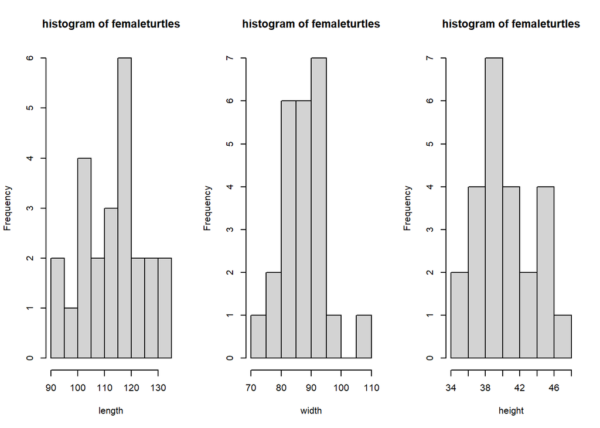

```r
par(mfrow=c(1,3))
hist(turtles_f[,1],main="histogram of femaleturtles",xlab=colnames(turtles_f[1]))
hist(turtles_f[,2],main="histogram of femaleturtles",xlab=colnames(turtles_f[2]))
hist(turtles_f[,3],main="histogram of femaleturtles",xlab=colnames(turtles_f[3]))
```

###### **성별에 따른 변수 쌍**

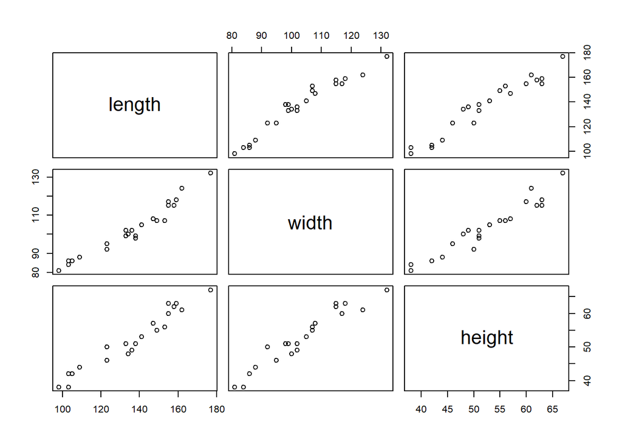

```r
par(mfrow=c(2,1))
plot(turtles_m)
```

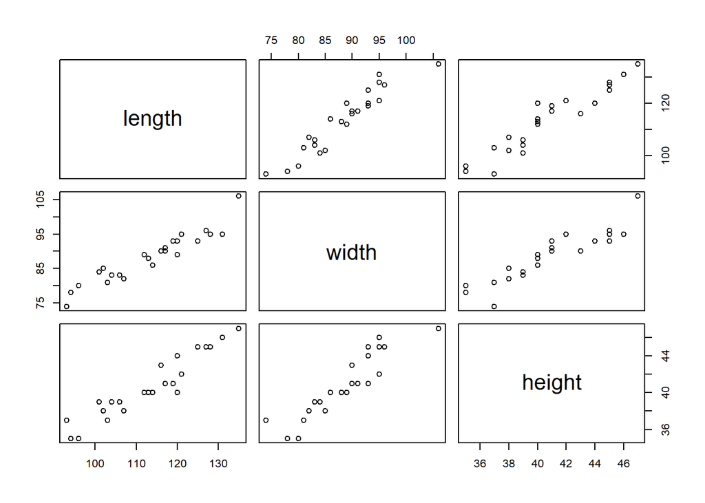

```r
plot(turtles_f)
```

###### **QQplot-3차원 동시고려**

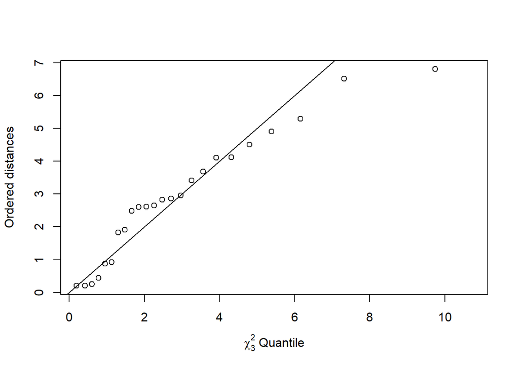

```r
tm<-turtles_m
tmcm<-colMeans(tm)
tms<-cov(tm)
tmd<-function(x){
  t(x-tmcm) %*% solve(tms) %*% (x-tmcm)
}
tmd<-apply(tm,1,tmd)
tmqc<-qchisq((1:nrow(tm)-1/2)/nrow(tm),df=3)
tmsd<-sort(tmd)
plot(tmqc,tmsd,xlab=expression(paste(chi[3]^2," Quantile")),ylab="Ordered distances",xlim=range(tmqc)*c(1,1.1))
abline(a=0,b=1)
```

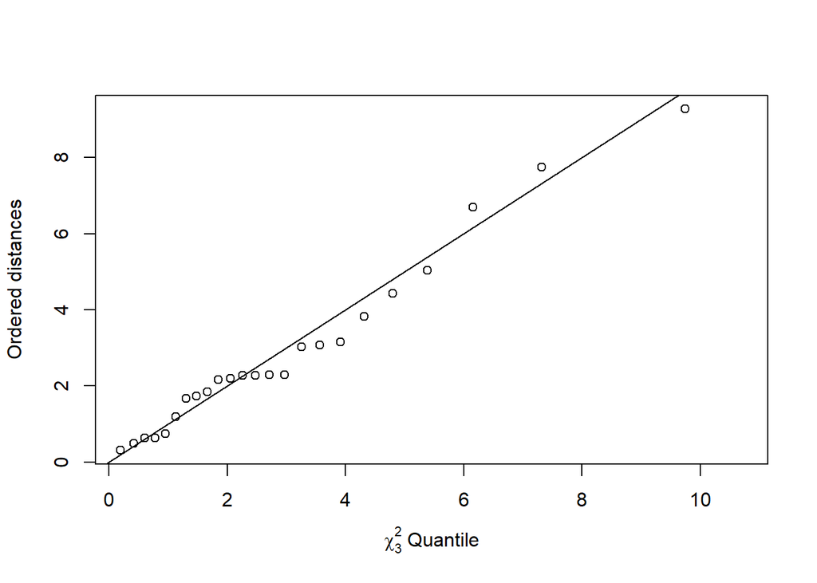

```r
tf<-turtles_f
tfcm<-colMeans(tf)
tfs<-cov(tf)
tfd<-function(x){
  t(x-tfcm) %*% solve(tfs) %*% (x-tfcm)
}
tfd<-apply(tf,1,tfd)
tfqc<-qchisq((1:nrow(tf)-1/2)/nrow(tf),df=3)
tfsd<-sort(tfd)
plot(tfqc,tfsd,xlab=expression(paste(chi[3]^2," Quantile")),ylab="Ordered distances",xlim=range(tfqc)*c(1,1.1))
abline(a=0,b=1)
```

##### **변수하나씩,pair,3차원 동시 고려해서 봐도 어느정도 정규분포를 따른다고 가정할 수 있다.**

##### **2.common variance**

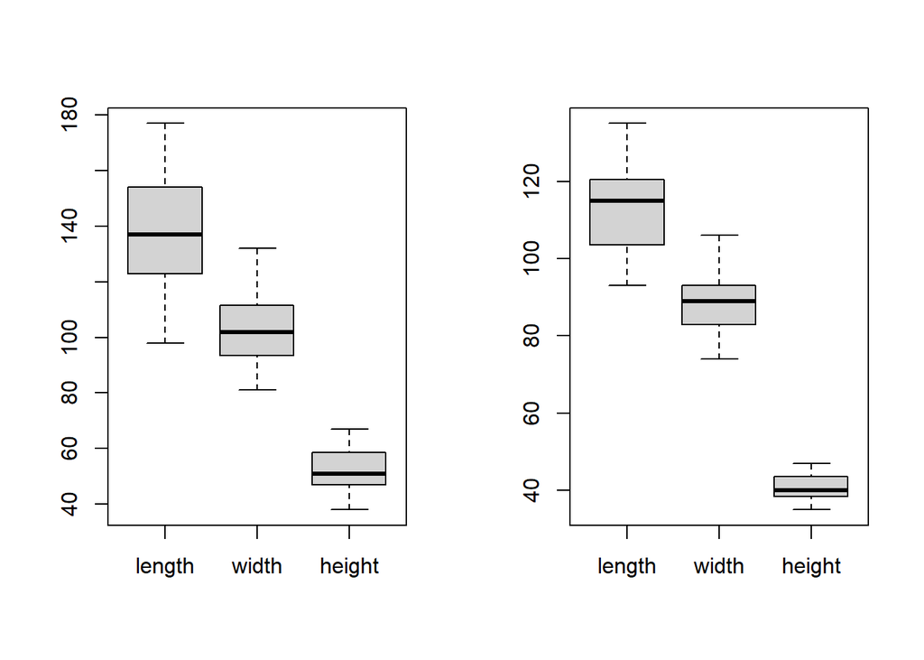

```r
par(mfrow=c(1,2))
boxplot(turtles_m)
boxplot(turtles_f)
```

###### **육안으로 볼 경우 결론 짓기 어렵다.**

```r
cov(turtles_m)
```

```
##          length    width    height
## length 451.5199 270.9746 165.95471
## width  270.9746 171.7319 101.84420
## height 165.9547 101.8442  64.73732
```

```r
cov(turtles_f)
```

```
##           length    width   height
## length 138.76630 79.14674 37.37500
## width   79.14674 50.04167 21.65399
## height  37.37500 21.65399 11.25906
```

```r
cor(turtles_m)
```

```
##           length     width    height
## length 1.0000000 0.9731162 0.9706748
## width  0.9731162 1.0000000 0.9659029
## height 0.9706748 0.9659029 1.0000000
```

```r
cor(turtles_f)
```

```
##           length     width    height
## length 1.0000000 0.9497846 0.9455580
## width  0.9497846 1.0000000 0.9122648
## height 0.9455580 0.9122648 1.0000000
```

###### **수치, 스케일링한 수치로 봤을때도 결론 짓기 어렵다.**

```r
library(biotools)
boxM(turtles[,-1],group=turtles[,1])
```

```
##
##  Box's M-test for Homogeneity of Covariance Matrices
##
## data:  turtles[, -1]
## Chi-Sq (approx.) = 23.405, df = 6, p-value = 0.0006716
```

정규성을 확인했으므로 ,수업시간에 배운 box m test를 해보면, p-value가 매우작은값으로,귀무가설을 기각한다. 즉,같다고가정할 수없다.

##### **(c) Find simultaneous confidence intervals**

##### **자유도 v구하기(같다고 가정 할 수 없으니)**

```r
tt<-t(turtles_d)%*%solve(1/n1*turtles_m_v+1/n2*turtles_f_v)%*%turtles_d   #T^2
s_t<-1/n1*turtles_m_v+1/n2*turtles_f_v                                    #S_T 행렬렬
vv<-1/(n1-1)*(t(turtles_d)%*%solve(s_t)%*%(1/n1*turtles_m_v)%*%solve(s_t)%*%(turtles_d)/tt)%*%(t(turtles_d)%*%solve(s_t)%*%(1/n1*turtles_m_v)%*%solve(s_t)%*%(turtles_d)/tt)+1/(n2-1)*(t(turtles_d)%*%solve(s_t)%*%(1/n2*turtles_m_v)%*%solve(s_t)%*%(turtles_d)/tt)%*%(t(turtles_d)%*%solve(s_t)%*%(1/n2*turtles_m_v)%*%solve(s_t)%*%(turtles_d)/tt)  #1/v 구하기 위함
v<-1/vv                                                                      #자유도 v
```

```r
simul_lower<-turtles_d-sqrt(p*(n1+n2-2)/(n1+n2-p-1)*qf(0.95,p,v))*sqrt(diag(turtles_m_v)/n1+diag(turtles_f_v)/n2)
simul_upper<-turtles_d+sqrt(p*(n1+n2-2)/(n1+n2-p-1)*qf(0.95,p,v))*sqrt(diag(turtles_m_v)/n1+diag(turtles_f_v)/n2)
turtles_CI_simul<-cbind(simul_lower,simul_upper)
turtles_CI_simul<-as.data.frame(turtles_CI_simul)
turtles_CI_simul
```

```
##        simul_lower simul_upper
## length    6.870614    38.46272
## width     4.609509    23.97382
## height    5.665544    17.00112
```

##### **(c) Find Bonferroni confidence intervals**

```r
bon_lower<-turtles_d-abs(qt(0.05/2/p,v))*sqrt(diag(turtles_m_v)/n1+diag(turtles_f_v)/n2)
bon_upper<-turtles_d+abs(qt(0.05/2/p,v))*sqrt(diag(turtles_m_v)/n1+diag(turtles_f_v)/n2)
turtles_CI_bon<-cbind(bon_lower,bon_upper)
turtles_CI_bon<-as.data.frame(turtles_CI_bon)
turtles_CI_bon
```

```
##        bon_lower bon_upper
## length  9.419217  35.91412
## width   6.171670  22.41166
## height  6.580010  16.08666
```

#### **simultaneous와 bonferroni intervals를 비교했을때, bonferroni interval이 보수적임을 다시 한번 확인 할 수 있다.**